# R3: Gathering, Cleaning data, 2022

# Analysis of San Francisco Police Calls for Service Data

- **Here is the original dataset: 3,048,797 records**

https://data.sfgov.org/Public-Safety/Police-Department-Calls-for-Service/hz9m-tj6z/data

– **Access the API**

https://datasf.org/opendata/developers/

– **Import from an API**

https://data.sfgov.org/resource/hz9m-tj6z.json

Load Data

```r
SF <- rio::import("SF_311_Jan29.xlsx", which = "SF Police_Department_Calls_for_")

#At Home: See Appendix to load data at home from Internet
```

- **Clean column names, Process dates**

```r
SF <- janitor::clean_names(SF)
#Process dates
SF$call_date2 <- ymd(SF$call_date)
SF$year <- year(SF$call_date2)
```

# Cleaning Dispositions

```
  Clean and structure the data you’ve gathered in preparation for analysis using tidyverse packages.
```

– **Total by disposition**

```r
Action <- SF %>%
  count(disposition) %>%
  arrange(desc(n))
head(Action)
```

```
##    disposition     n
## 1          HAN 51064
## 2          ADV 49823
## 3          GOA 31951
## 4          CIT  6053
## 5          UTL  4994
## 6 Not recorded  4339
```

– **Decode Police Radio Codes**

A guide to what these disposition codes mean

```r
copspeak <- rio::import("Radio_Codes_2016.xlsx", which ="RadioCodes")
head(copspeak)
```

```
##   Category    Code                                     Description
## 1    Codes  CODE 3                              EMERGENCY RESPONSE
## 2    Codes  CODE 4 No Further Assistance Required (Specify Reason)
## 3    Codes CODE 33                       EMERGENCY - CLEAR CHANNEL
## 4    Codes    10-1                                Receiving Poorly
## 5    Codes    10-2                                  Receiving Well
## 6    Codes    10-4                                Message Received
```

```r
#In case the file isn't there:
#copspeak <- rio::import("https://github.com/profrobwells/Guest_Lectures/blob/master/Intro_to_R_2022/Radio_Codes_2016.xlsx?raw=true", which ="RadioCodes")

#HAN = Handled
#ADV = Advised
#GOA = Gone on arrival

#view(copspeak)
```

- **Serious Actions**: Create a table with the serious actions including citations and arrests police took in the dispositions

Arrest, Cited, Criminal Activation, SF Fire Dept Medical Staff engaged

```r
Busted <- SF %>%
  filter(disposition == "ARR" | disposition == "CIT" | disposition == "CRM" | disposition == "SFD") %>%
  count(disposition) %>%
  arrange(desc(n))
head(Busted)
```

```
##   disposition    n
## 1         CIT 6053
## 2         ARR  441
## 3         SFD   35
## 4         CRM    1
```

Find out when nothing happened with the officer's investigation. A table filtering the dispositions column to show “no disposition” or “gone on arrival”

```r
Nothing <- SF %>%
  filter(disposition == "ND" | disposition == "GOA")
```

– **Translate Cop Jargon to English**

The disposition column is in cop-speak. We need to clean it up

Step #1: Use mutate to duplicate the column you want to mess with

– **Mutate command**

```
Create new column(s) in the data, or change existing column(s).
mutate() adds new variables and preserves existing
Example:
mtcars <- as.data.frame(mtcars)
View(mtcars)

mtcars2 <- mtcars %>% as_tibble() %>% mutate(
cyl2 = cyl * 2,
cyl4 = cyl2 * 2)
```

```r
SF <- SF %>%
  mutate(disposition1 = disposition)
```

– **Rename specific text strings**

Example:

```
 str_replace_all(test.vector, pattern=fixed('-'),     replacement=fixed(':') )
 Details on string manipulation:
 https://dereksonderegger.github.io/570L/13-string-manipulation.html
```

Replace ABA with “Abated”

```r
SF$disposition1 <- str_replace_all(SF$disposition1, pattern=fixed('ABA'), replacement=fixed('Abated') )
#Again with ADM
SF$disposition1 <- str_replace_all(SF$disposition1, pattern=fixed('ADM'), replacement=fixed('Admonished') )
```

–**Clean disposition types**

```r
SF <- SF %>%
   mutate(disposition1 = case_when(
     str_detect(disposition, "CIT") ~ "Cited",
     str_detect(disposition, "CRM") ~ "Criminal",
     str_detect(disposition, "GOA") ~ "Gone",
     str_detect(disposition, "HAN") ~ "Handled",
     str_detect(disposition, "NCR") ~ "No_Criminal",
     str_detect(disposition, "ND") ~ "No_Dispo",
     str_detect(disposition, "NOM") ~ "No_Merit",
     str_detect(disposition, "PAS") ~ "PlaceSecure",
     str_detect(disposition, "REP") ~ "Report",
     str_detect(disposition, "SFD") ~ "Medical",
     str_detect(disposition, "UTL") ~ "Unfound",
     str_detect(disposition, "VAS") ~ "Vehicle-Secure",
     str_detect(disposition, '22') ~ "Cancel",
     str_detect(disposition, "Not recorded") ~ "NotRecorded",
     str_detect(disposition, "CAN") ~ "Cancel",
     str_detect(disposition, "ADV") ~ "Advised",
     str_detect(disposition, "ARR") ~ "Arrest",
      TRUE ~ disposition1
   ))
```

Compare our renamed variables to the original disposition

```r
Action <- SF %>%
  count(disposition1, disposition) %>%
  arrange(desc(n))
head(Action)
```

```
##   disposition1  disposition     n
## 1      Handled          HAN 51064
## 2      Advised          ADV 49823
## 3         Gone          GOA 31951
## 4        Cited          CIT  6053
## 5      Unfound          UTL  4994
## 6  NotRecorded Not recorded  4339
```

Chart Dispositions

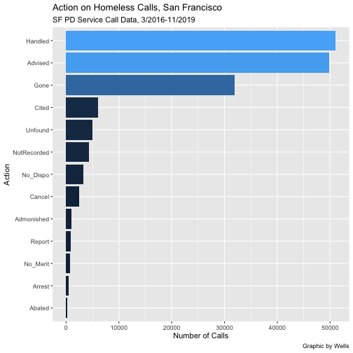

```r
Action %>%
  filter(n > 100) %>%
  ggplot(aes(x = reorder(disposition1, n), y = n, fill=n)) +
  geom_bar(stat = "identity", show.legend = FALSE) +
  coord_flip() +    #this makes it a horizontal bar chart instead of vertical
  labs(title = "Action on Homeless Calls, San Francisco",
       subtitle = "SF PD Service Call Data, 3/2016-11/2019",
       caption = "Graphic by Wells",
       y="Number of Calls",
       x="Action")
```

# Cleaning Crime Data

- **Parse out crime type name**

– **Tabulate types of events**

```r
Types <- SF %>% count(original_crime_type_name) %>%
  group_by(original_crime_type_name) %>%
  arrange(desc(n))
head(Types)
```

```
## # A tibble: 6 × 2
## # Groups:   original_crime_type_name [6]
##   original_crime_type_name      n
##   <chr>                     <int>
## 1 Homeless Complaint       142780
## 2 915                        9283
## 3 919                        2879
## 4 915 Sleeper                 290
## 5 920                         226
## 6 915/919                     161
```

```r
# 915/919
# 915 Sleeper
# Some have commentary
# 915 Encampment
```

We need to unpack that

- **Cleaning Sequence**

```r
#convert all text to lowercase
SF$crime1 <- tolower(SF$original_crime_type_name)

#Replace / with a space
SF$crime1 <- gsub("/", " ", SF$crime1)

#Replace '
SF$crime1 <- gsub("'", "", SF$crime1)

#fix space in homeless complaint
SF$crime1 <- gsub("homeless complaint", "homeless_complaint", SF$crime1)

#split crime1 into three new columns
SF <- separate(data = SF, col = crime1, into = c("crime2", "crime3", "crime4"), sep = " ", extra = "merge", fill = "right")
```

For this lesson, we will clean just one column. See Appendix on the method to clean and construct a new dataframe with all of the columns

```r
#Clean Crime2
SF <- SF %>%
   mutate(crime_cleaned = case_when(
     str_detect(crime2, '919') ~ "sit_lying",
     str_detect(crime2, '915') ~ "homeless_complaint",
     str_detect(crime2, '915s') ~ "homeless_complaint",
     str_detect(crime2, '915x') ~ "homeless_complaint",
     str_detect(crime2, '909') ~ "interview",
     str_detect(crime2, '902') ~ "aggress_solicit",
     str_detect(crime2, '811') ~ "intoxicated",
     str_detect(crime2, '601') ~ "trespasser",
     str_detect(crime2, "aggressive") ~ "aggressive",
     str_detect(crime2, "chop shop") ~ "chop_shop",
     str_detect(crime2, "dog") ~ "dog",
     str_detect(crime2, "drugs") ~ "drugs",
     str_detect(crime2, "homeless_complaint") ~ "homeless_complaint",
     str_detect(crime2, "music") ~ "music",
     str_detect(crime2, "panhandling") ~ "panhandling",
     str_detect(crime2, "poss") ~ "possession",
     str_detect(crime2, "sleep") ~ "sleep",
     str_detect(crime2, "tent") ~ "tent",
     TRUE ~ ""
   ))
```

```r
#count the offenses
#remember this is a partial total
SF %>%
  count(crime_cleaned) %>%
  arrange(desc(n))
```

```
##         crime_cleaned      n
## 1  homeless_complaint 153501
## 2           sit_lying   3048
## 3                        412
## 4               drugs     88
## 5          trespasser     74
## 6          possession     41
## 7          aggressive     36
## 8         intoxicated     31
## 9               music      3
## 10                dog      1
## 11          interview      1
## 12        panhandling      1
```

– **Compare to Types Table**

```r
#Look at the Types table: some columns have one code, some have two.
Types %>%
  distinct()
```

```
## # A tibble: 526 × 2
## # Groups:   original_crime_type_name [526]
##    original_crime_type_name      n
##    <chr>                     <int>
##  1 Homeless Complaint       142780
##  2 915                        9283
##  3 919                        2879
##  4 915 Sleeper                 290
##  5 920                         226
##  6 915/919                     161
##  7 915 Encampment               88
##  8 915/sleeper                  64
##  9 915's                        62
## 10 915 Aggressive               49
## # … with 516 more rows
```

– **Chart Crimes**

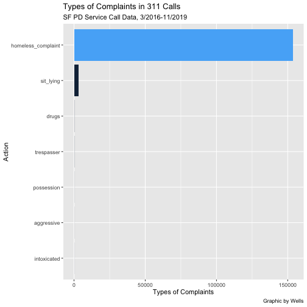

```r
SF %>%
  count(crime_cleaned) %>%
  filter(!crime_cleaned =="") %>%
  filter(n > 30) %>%
  ggplot(aes(x = reorder(crime_cleaned, n), y = n, fill=n)) +
  geom_bar(stat = "identity", show.legend = FALSE) +
  coord_flip() +    #this makes it a horizontal bar chart instead of vertical
  labs(title = "Types of Complaints in 311 Calls",
       subtitle = "SF PD Service Call Data, 3/2016-11/2019",
       caption = "Graphic by Wells",
       y="Types of Complaints",
       x="Action")
```

- **Question**: What is the trend for arrests over the time period?

Process dates using lubidate

```r
SF <- SF %>%
  mutate(yearmo = format(call_date, "%Y-%m"))
```

[figure not shown]

```r
SF %>%
  filter(grepl("ARR", disposition)) %>%
  count(yearmo) %>%
  group_by(yearmo) %>%
  ggplot(aes(x = yearmo, y = n, fill=n)) +
  geom_bar(stat = "identity", show.legend = FALSE) +
  geom_smooth(method = lm, se=FALSE, color = "red") +
  theme(axis.text.x = element_text(angle=90)) +
  #Changes angle of x axis labels
  #coord_flip() +    #this makes it a horizontal bar chart instead of vertical
  labs(title = "Arrest Trends on Homeless Calls in San Francisco",
       subtitle = "Arrests Based on SF PD Service Call Data by Month 2017-2019",
       caption = "Graphic by Wells",
       y="Number of Calls",
       x="Year")
```

- **Question**: What are the hours most likely for complaints?

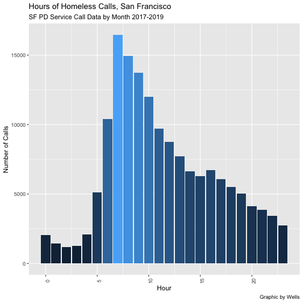

```r
#format to hours
SF$hour <- hour(SF$call_date_time)
SF %>%
  count(hour) %>%
  group_by(hour) %>%
  ggplot(aes(x = hour, y = n, fill=n)) +
  geom_bar(stat = "identity", show.legend = FALSE) +
  theme(axis.text.x = element_text(angle=90)) +
  #Changes angle of x axis labels
  #coord_flip() +    #this makes it a horizontal bar chart instead of vertical
  labs(title = "Hours of Homeless Calls, San Francisco",
       subtitle = "SF PD Service Call Data by Month 2017-2019",
       caption = "Graphic by Wells",
       y="Number of Calls",
       x="Hour")
```

# Part 5: Using Mutate, Pct Calcs

Chart the number of calls by year and month

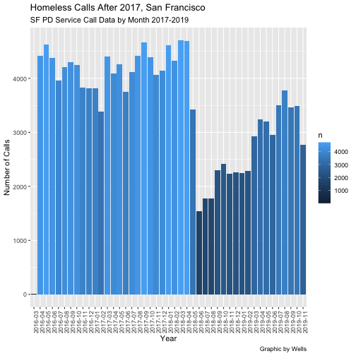

```r
SF %>%
  count(yearmo) %>%
  group_by(yearmo) %>%
  ggplot(aes(x = yearmo, y = n, fill=n)) +
  geom_bar(stat = "identity") +
  theme(axis.text.x = element_text(angle=90)) +
  #Changes angle of x axis labels
  #coord_flip() +    #this makes it a horizontal bar chart instead of vertical
  labs(title = "Homeless Calls After 2017, San Francisco",
       subtitle = "SF PD Service Call Data by Month 2017-2019",
       caption = "Graphic by Wells",
       y="Number of Calls",
       x="Year")
```

Build a summary table with the days of the week with the greatest number of calls. Create a graphic. Then build a table to see if the complaints vary by day

```r
SF <- SF %>%
  mutate(weekday = wday(call_date, label=TRUE, abbr=FALSE))
Weekday_Count <- SF %>%
  select(weekday, crime_id) %>%
  count(weekday) %>%
  arrange(desc(n))
```

Graphic of calls by weekdays

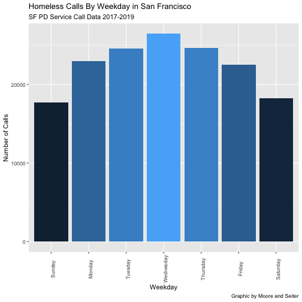

```r
Weekday_Count %>%
  ggplot(aes(x = weekday, y = n, fill=n)) +
  geom_bar(stat = "identity", show.legend = FALSE) +
  theme(axis.text.x = element_text(angle=90)) +
  #Changes angle of x axis labels
  #coord_flip() +    #this makes it a horizontal bar chart instead of vertical
  labs(title = "Homeless Calls By Weekday in San Francisco",
       subtitle = "SF PD Service Call Data 2017-2019",
       caption = "Graphic by Moore and Seiter",
       y="Number of Calls",
       x="Weekday")
```

# Appendix

#At Home: Load data at home from Internet

```r
SF <- rio::import("https://github.com/profrobwells/HomelessSP2020/blob/master/Data/SF_311_Jan29.xlsx?raw=true", which = "SF Police_Department_Calls_for_")
```

#police radio codes data https://data.sfgov.org/api/views/hz9m-tj6z/files/b60ee24c-ae7e-4f0b-a8d5-8f4bd29bf1de?download=true&filename=Radio%20Codes%202016.xlsx

### How to Clean all of the Crime Columns

- **Cleaning Sequence**

```r
#convert all text to lowercase
SF$crime1 <- tolower(SF$original_crime_type_name)
```

[output not shown]

```r
#Replace / with a space
SF$crime1 <- gsub("/", " ", SF$crime1)
```

[output not shown]

```r
#Replace '
SF$crime1 <- gsub("'", "", SF$crime1)
```

[output not shown]

```r
#fix space in homeless complaint
SF$crime1 <- gsub("homeless complaint", "homeless_complaint", SF$crime1)
```

[output not shown]

```r
#split crime1 into three new columns
SF <- separate(data = SF, col = crime1, into = c("crime2", "crime3", "crime4"), sep = " ", extra = "merge", fill = "right")
```

[output not shown]

For this lesson, we will clean just one column. See Appendix on the method to clean and construct a new dataframe with all of the columns

```r
#Clean Crime2
SF <- SF %>%
   mutate(crime_cleaned = case_when(
     str_detect(crime2, '919') ~ "sit_lying",
     str_detect(crime2, '915') ~ "homeless_complaint",
     str_detect(crime2, '915s') ~ "homeless_complaint",
     str_detect(crime2, '915x') ~ "homeless_complaint",
     str_detect(crime2, '909') ~ "interview",
     str_detect(crime2, '902') ~ "aggress_solicit",
     str_detect(crime2, '811') ~ "intoxicated",
     str_detect(crime2, '601') ~ "trespasser",
     str_detect(crime2, "aggressive") ~ "aggressive",
     str_detect(crime2, "chop shop") ~ "chop_shop",
     str_detect(crime2, "dog") ~ "dog",
     str_detect(crime2, "drugs") ~ "drugs",
     str_detect(crime2, "homeless_complaint") ~ "homeless_complaint",
     str_detect(crime2, "music") ~ "music",
     str_detect(crime2, "panhandling") ~ "panhandling",
     str_detect(crime2, "poss") ~ "possession",
     str_detect(crime2, "sleep") ~ "sleep",
     str_detect(crime2, "tent") ~ "tent",
     TRUE ~ ""
   ))
```

[output not shown]

```r
#Clean Crime3
SF <- SF %>%
   mutate(crime_cleaned1 = case_when(
     str_detect(crime3, '919') ~ "sit_lying",
     str_detect(crime3, '915') ~ "homeless_complaint",
     str_detect(crime3, '915s') ~ "homeless_complaint",
     str_detect(crime3, '915x') ~ "homeless_complaint",
     str_detect(crime3, '909') ~ "interview",
     str_detect(crime3, '902') ~ "aggress_solicit",
     str_detect(crime3, '811') ~ "intoxicated",
     str_detect(crime3, '601') ~ "trespasser",
     str_detect(crime3, "aggressive") ~ "aggressive",
     str_detect(crime3, "chop shop") ~ "chop_shop",
     str_detect(crime3, "dog") ~ "dog",
     str_detect(crime3, "drugs") ~ "drugs",
     str_detect(crime3, "homeless_complaint") ~ "homeless_complaint",
     str_detect(crime3, "music") ~ "music",
     str_detect(crime3, "panhandling") ~ "panhandling",
     str_detect(crime3, "poss") ~ "possession",
     str_detect(crime3, "sleep") ~ "sleep",
     str_detect(crime3, "tent") ~ "tent",
     TRUE ~ ""
   ))
```

[output not shown]

```r
#Clean Crime4
SF <- SF %>%
   mutate(crime_cleaned2 = case_when(
     str_detect(crime4, '919') ~ "sit_lying",
     str_detect(crime4, '915') ~ "homeless_complaint",
     str_detect(crime4, '915s') ~ "homeless_complaint",
     str_detect(crime4, '915x') ~ "homeless_complaint",
     str_detect(crime4, '909') ~ "interview",
     str_detect(crime4, '902') ~ "aggress_solicit",
     str_detect(crime4, '811') ~ "intoxicated",
     str_detect(crime4, '601') ~ "trespasser",
     str_detect(crime4, "aggressive") ~ "aggressive",
     str_detect(crime4, "chop shop") ~ "chop_shop",
     str_detect(crime4, "dog") ~ "dog",
     str_detect(crime4, "drugs") ~ "drugs",
     str_detect(crime4, "homeless_complaint") ~ "homeless_complaint",
     str_detect(crime4, "music") ~ "music",
     str_detect(crime4, "panhandling") ~ "panhandling",
     str_detect(crime4, "poss") ~ "possession",
     str_detect(crime4, "sleep") ~ "sleep",
     str_detect(crime4, "tent") ~ "tent",
     TRUE ~ ""
   ))
```

[output not shown]

–**Create a New Dataframe to Tabulate the Crimes**

```r
#Three mini dataframes with two columns
crime1 <- SF %>%
  select(report_date, crime_cleaned)
```

[output not shown]

```r
crime2 <- SF %>%
  select(report_date, crime_cleaned1) %>%
  rename(crime_cleaned = crime_cleaned1)
```

[output not shown]

```r
crime3 <- SF %>%
  select(report_date, crime_cleaned2) %>%
  rename(crime_cleaned = crime_cleaned2)
```

[output not shown]

```r
#Create a new dataframe called Total_Calls_Master
Total_Calls_Master <- rbind(crime1, crime2, crime3)
```

[output not shown]

```r
#filter blank values, rename columns
Total_Calls_Master <- Total_Calls_Master %>%
  filter(!crime_cleaned=="") %>%
  rename(Date=report_date, Complaint = crime_cleaned)
```

[output not shown]

```r
#export
write_csv(Total_Calls_Master, "Total_Calls_Master.csv")
```

[output not shown]

–**Fact Check**

```r
x <- SF %>%
  select(crime_cleaned) %>%
  count(crime_cleaned) %>%
  arrange(desc(n))
```

[output not shown]

```r
head(x)
```

[output not shown]

```r
Crime_Sums <- Total_Calls_Master %>%
  select(Complaint) %>%
  count(Complaint) %>%
  arrange(desc(n))
```

[output not shown]

```r
head(Crime_Sums)
```

[output not shown]

Make into html table

```r
#install.packages("kableExtra")
library(kableExtra)
```

```r
#This makes html tables called "kables"
Crime_Sums %>%
  kable() %>%
  kable_styling("striped")
```

[output not shown]

-**30**